# 随机与抽样

## 统计模拟

### 几种常见的模拟方法

例：用模拟的方法检验中心极限定理

设$\left\{x_{n}\right\}$是独立同部分随机变量序列，满足$\mathrm{E}\left(X_{1}\right)=\mu,\quad\operatorname{Var}\left(X_{1}\right)=\sigma^{2},\quad 0<\sigma^{2}<\infty$。则前$n$个变量之和的标准化变量$Y_{n}^{*}=\frac{X_{1}+X_{2}+\ldots+X_{n}-n \mu}{\sqrt{n} \sigma}$的分布函数将随着$n \rightarrow \infty$而依概率收敛于标准正态分布，或$\frac{\overline{X}-\mu}{\sigma / \sqrt{n}}$的分布随着$n \rightarrow \infty$而依概率收敛于标准正态分布。

#### 二项分布模拟中心极限定理

假如$\mathrm{z} \sim \mathrm{b}(\mathrm{n}, \mathrm{p})$，则其标准化变量$x=\frac{(\mathrm{Z}-\mathrm{np})}{\sqrt{\mathrm{np}(1-\mathrm{p})}}$。随着$n \rightarrow \infty$，x的分布而依概率收敛于标准正态分布。该定理也称为德莫弗－拉普拉斯定理。至于这个定理是否正确，除了数学上的严格证明外，也可用统计模拟方法检验它。

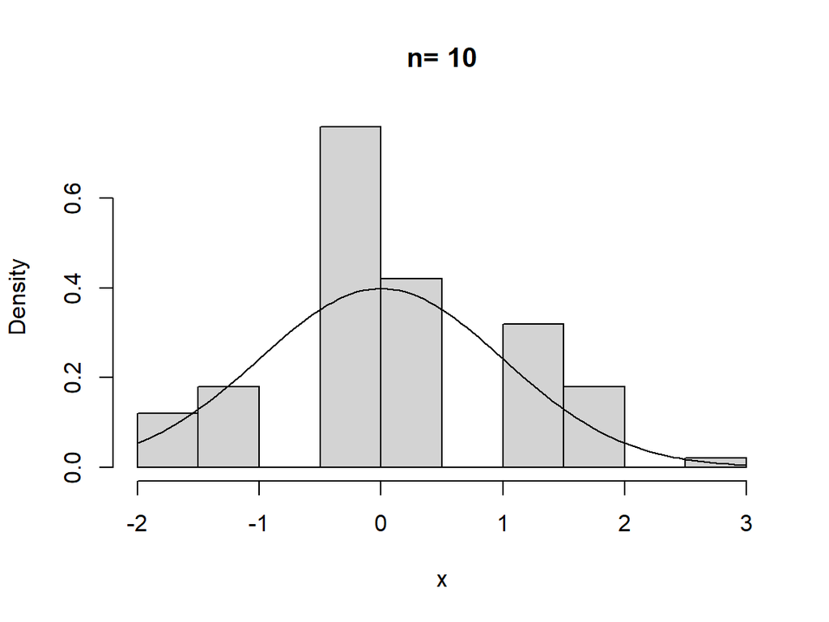

```r
# 首先介绍如何用R生成二项分布随机数的标准化变量
n <- 10
p <- 0.25
z <- rbinom(1, n, p)
x <- (z - n * p) / sqrt(n * p * (1 - p))

# 这是一个随机数标准化后的结果，我们需要产生很多随机数并观察它们的分布情况，比如需要产生100个这样的随机数
m <- 100 # m为模拟次数
z <- rbinom(m, n, p) # 产生100个二项随机数
x <- (z - n * p) / sqrt(n * p * (1 - p)) # 对100个二项随机数标准化
hist(x, prob = T, main = paste("n=", n))
curve(dnorm(x), add = T) # 添加正态曲线
```

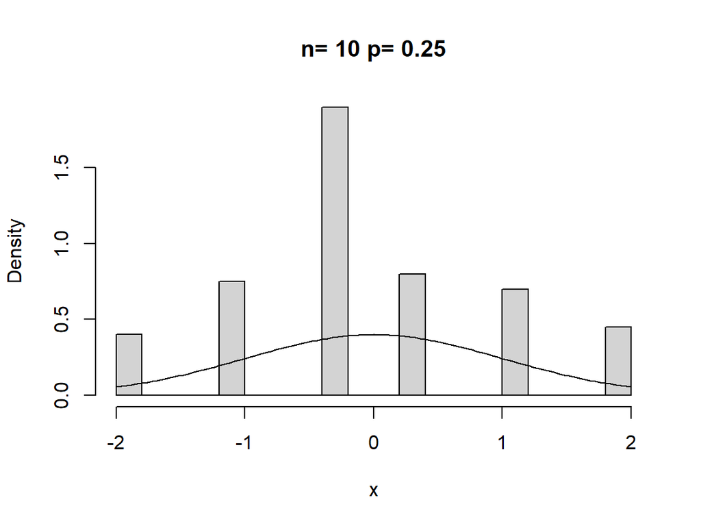

```r
sim.clt <- function(m = 100, n = 10, p = 0.25) {
  z <- rbinom(m, n, p)
  x <- (z - n * p) / sqrt(n * p * (1 - p))
  hist(x, prob = T, breaks = 20, main = paste("n=", n, "p=", p))
  curve(dnorm(x), add = T)
}
sim.clt() # 默认m=100，n=10，p=0.25
```

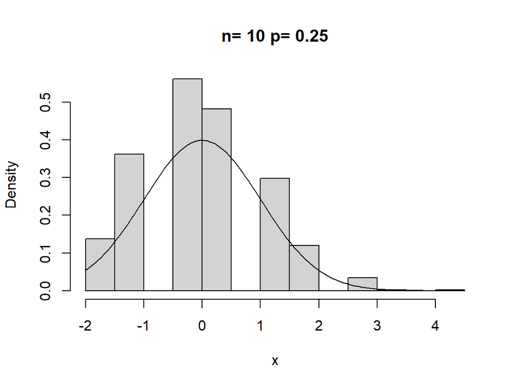

```r
sim.clt(1000) # 取m=1000，n=10，p=0.25
```

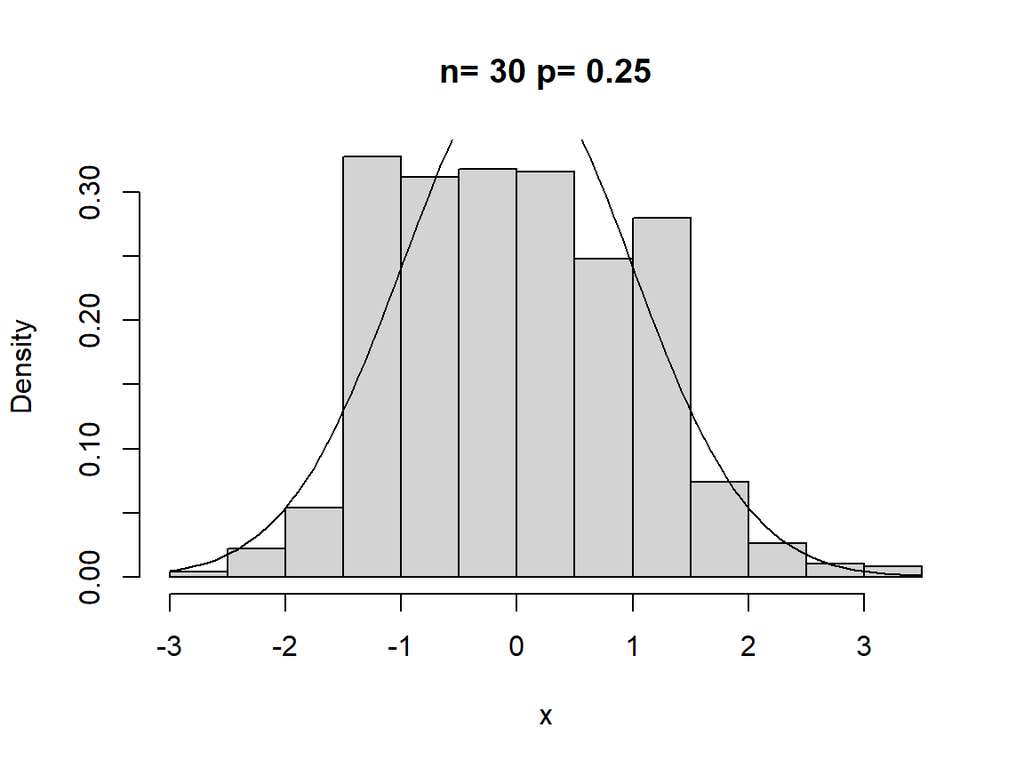

```r
sim.clt(1000, 30) # 取m=1000，n=30，p=0.25
```

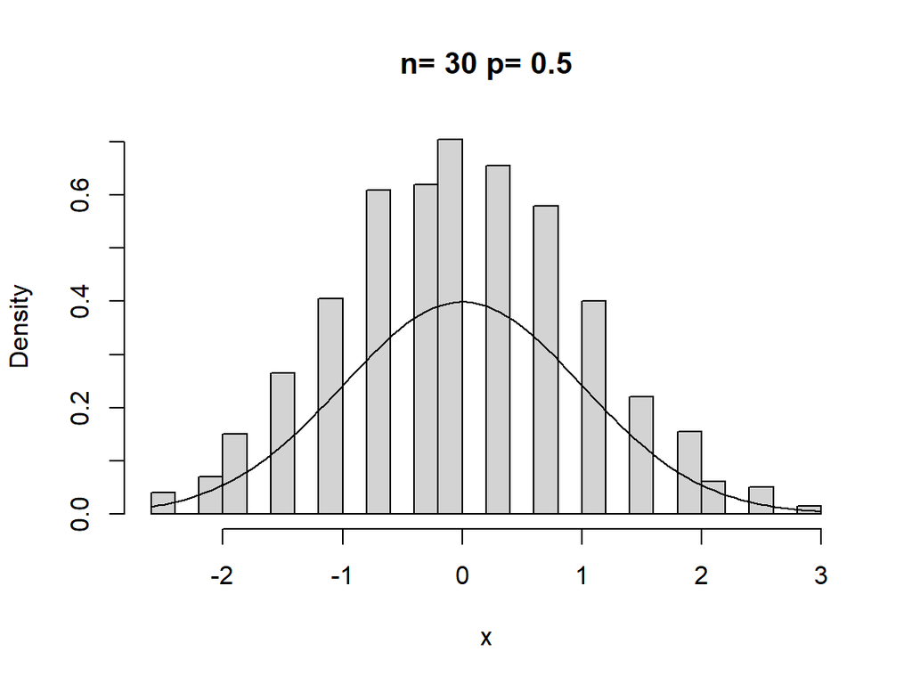

```r
sim.clt(1000, 30, 0.5) # 取m=1000，n=30，p=0.5
```

#### 正态概率模拟

能比直方图更好地判定随机数是否近似服从正态分布的是正态概率图。其基本思想是作样本分位数与理论分位数的散点图，看图像是否近似在一条直线上。分位数比中位数、下四分位数Q1和上四分位数Q3等更具一般性。q分位数就是累积概率小于q％所对应的值，所以25％分位数就是Q1，50%分位数就是中位数，75％分位数就是Q3。

用R来画正态概率图很简单，只要使用函数qqnorm()和qqline()，其中qqline是用来添加参考线（并不是回归线）。

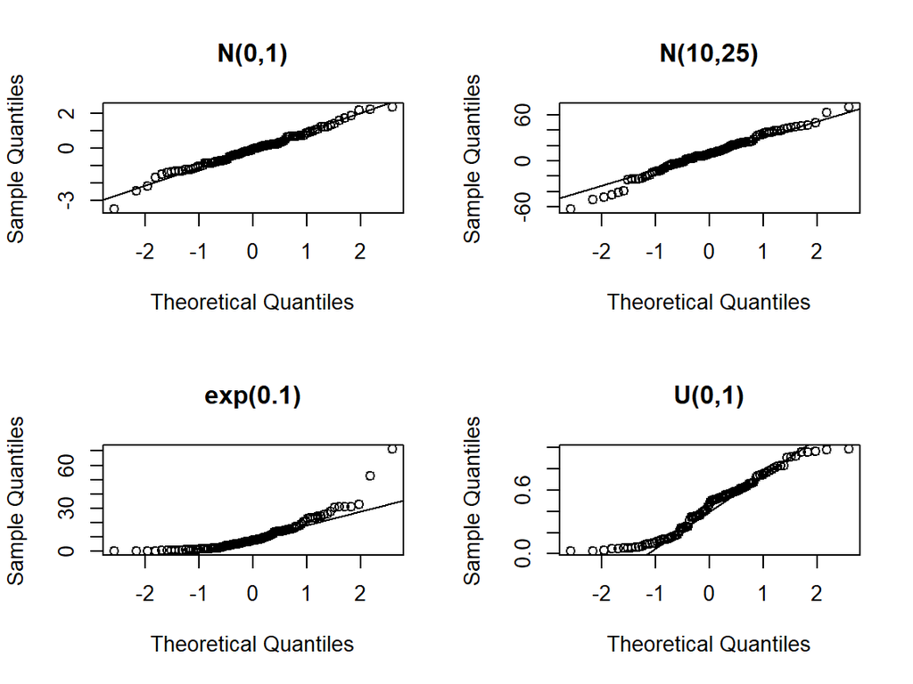

```r
# 例:分别产生100个均值为0、标准差为1的正态分布随机数，均值为10、标准差为5的正态分布随机数，均值为10的指数分布，[0,1]上的均匀分布。再分别作它们的正态概率图。

par(mfrow = c(2, 2)) # 设置2行2列的作图窗口
x <- rnorm(100, 0, 1)
qqnorm(x, main = "N(0,1)")
qqline(x) # 画QQ图并添加qq线
x <- rnorm(100, 10, 25)
qqnorm(x, main = "N(10,25)")
qqline(x)
x <- rexp(100, 1 / 10)
qqnorm(x, main = "exp(0.1)")
qqline(x)
x <- runif(100, 0, 1)
qqnorm(x, main = "U(0,1)")
qqline(x)
```

```r
par(mfrow = c(1, 1))
```

第一、第二（上面）两个图的散点近似分布在参考线上，所以服从正态分布，而第三（下面左边）个图的散点严重偏离参考线，第四个图两头翘尾，可认为这两个图不服从正态分布。

### 编写模拟函数

sim.fun()函数是专门用来解决这个问题的，只要编写一个用来生成随机数的函数，然后剩下的工作就交给sim.fun来做。下面编写泛式sim.fun函数（泛式是指函数是虚构的）

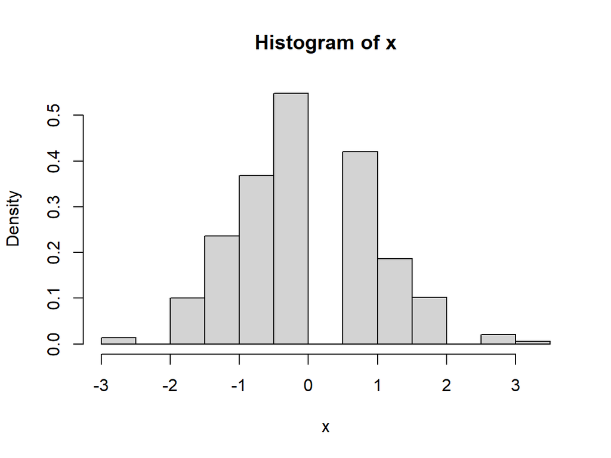

```r
sim.fun <- function(m, f, ...) # m为模拟样本次数，f为需模拟的函数
{
  sample <- 1:m
  for (i in 1:m) {
    sample[i] <- f(...)
  }
  sample
}


# 二项分布样本均值的标准化值
f <- function(n = 10, p = 0.5) {
  s <- rbinom(1, n, p)
  (s - n * p) / sqrt(n * p * (1 - p))
}
x <- sim.fun(1000, f) # 1000个样本，每个样本的样本量为10
hist(x, prob = T)
```

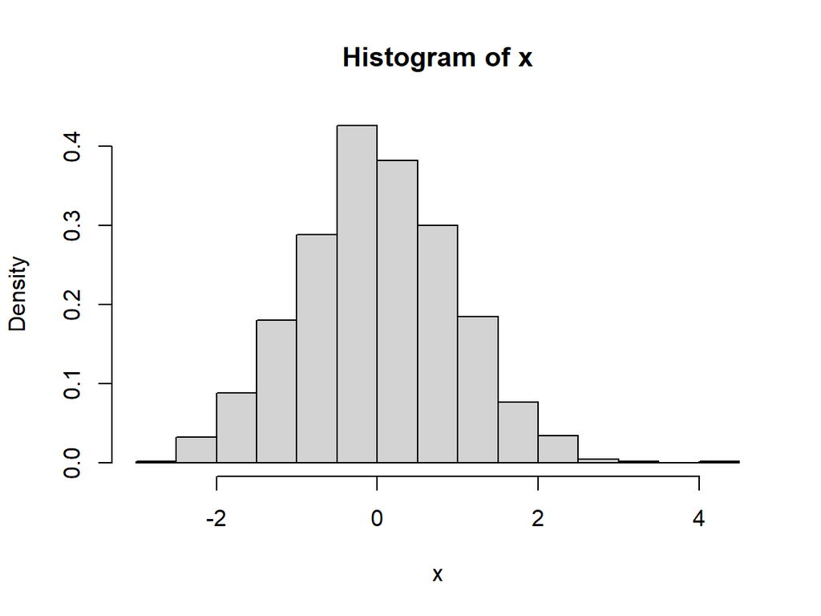

```r
# 均匀分布样本均值的标准化值
f <- function(n = 10) {
  mean(runif(n) - 1 / 2) / (1 / sqrt(12 * n))
}
x <- sim.fun(1000, f)
hist(x, prob = T)
```

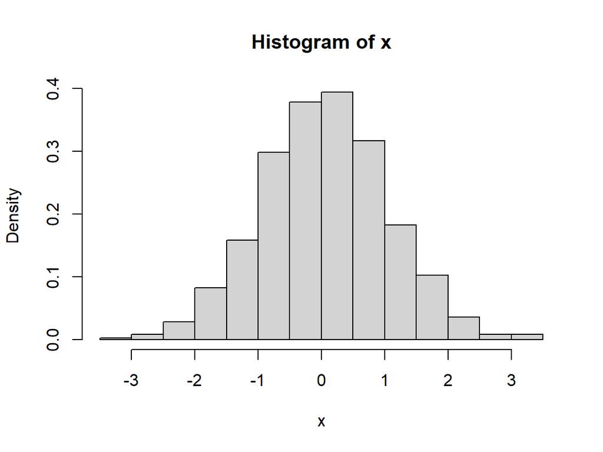

```r
# 正态分布样本均值的标准化值
f <- function(n = 10, mu = 0, sigma = 1) {
  r <- rnorm(n, mu, sigma)
  (mean(r) - mu) / (sigma / sqrt(n))
}
x <- sim.fun(1000, f) # 模拟1000个样本量为10的N(0,1)随机数
hist(x, breaks = 10, prob = T)
```

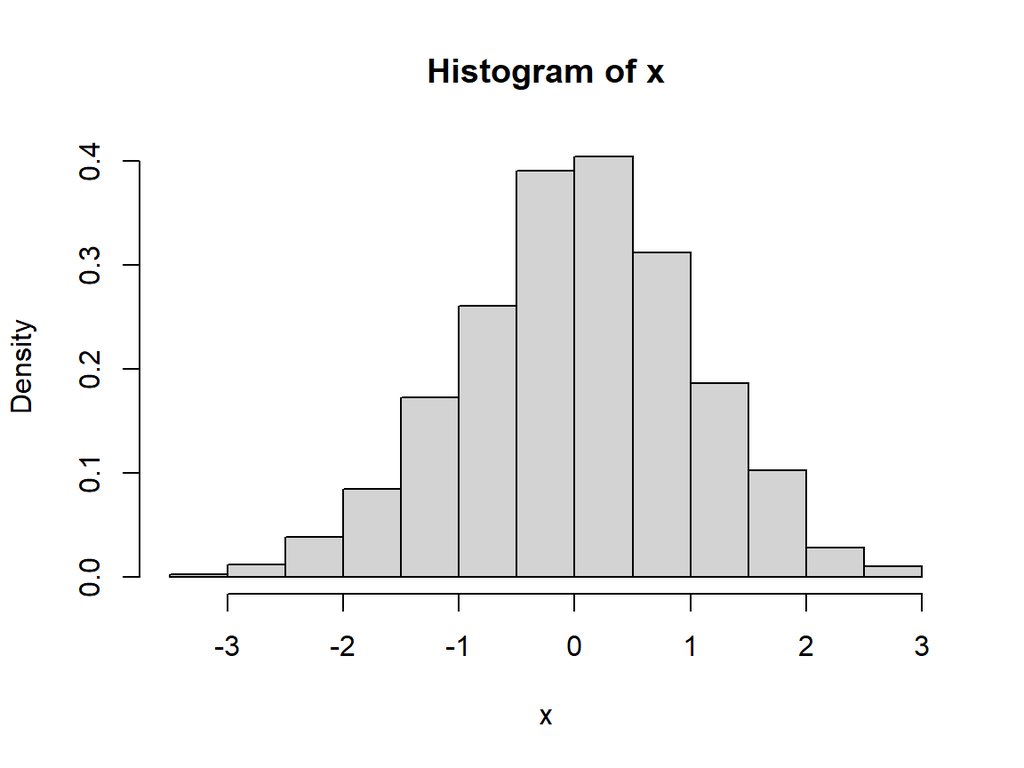

```r
x <- sim.fun(1000, f, 30, 5, 2) # 模拟1000个样本量为30的N(5,4)随机数
hist(x, breaks = 10, prob = T)
```

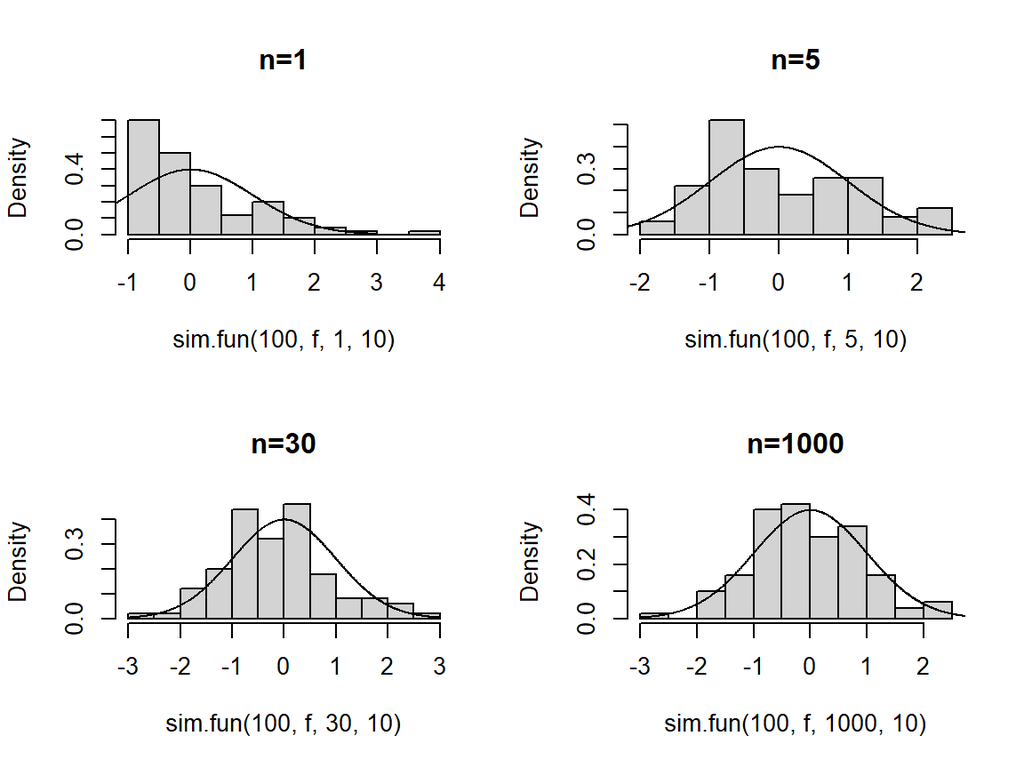

```r
# 指数分布样本均值的标准化值，该分布的均值和标准差都是10
f <- function(n, mu = 10) {
  (mean(rexp(n, 1 / mu) - mu)) / (mu / sqrt(n))
}
x <- seq(-3, 3, 0.01)
par(mfrow = c(2, 2))
hist(sim.fun(100, f, 1, 10), prob = T, main = "n=1")
points(x, dnorm(x, 0, 1), type = "l")
hist(sim.fun(100, f, 5, 10), prob = T, main = "n=5")
points(x, dnorm(x, 0, 1), type = "l")
hist(sim.fun(100, f, 30, 10), prob = T, main = "n=30")
points(x, dnorm(x, 0, 1), type = "l")
hist(sim.fun(100, f, 1000, 10), prob = T, main = "n=1000")
points(x, dnorm(x, 0, 1), type = "l")
```

```r
par(mfrow = c(1, 1))
# 可见随着样本量n的增大，样本均值所服从的分布越来越接近于正态分布
```